Extreme Value Theory for Anomaly Detection

[figure not shown]

```python
import tensorflow as tf
import tensorflow_probability as tfp
import numpy as np
import pandas as pd
import matplotlib.pyplot as plt
import os
import logging

from celluloid import Camera
from IPython.core.display import HTML
from matplotlib.animation import FuncAnimation
from sklearn.preprocessing import StandardScaler
from tensorflow import keras
from typing import Protocol, Sequence, Union, Tuple, List, TypeVar, Callable

tfd = tfp.distributions
```

# Extreme Value Theory and Anomaly Detection

Extreme value theory (EVT) usually deals with tails of univariate probability distributions, i.e. with events that are rare because they are large. Anomaly detection deals with events that rare but not necessarily large. Therefore, the topic of anomaly detection is more general than EVT.

Despite the smaller applicability of EVT techniques, they are still a valuable addition to the anomaly detectionist's toolbox. In several situations, anomalies directly correspond to large deviations from some (possibly running) mean - e.g. for sensor data, intrusion attacks based on the number of calls and others.

However, even for entirely different definitions of anomaly, most detection algorithms will produce a scalar outlier score for each datapoint. EVT can then be used as a probabilistic framework for analyzing the univariate distribution of outlier scores and help determine meaningful thresholds for separating anomalous from normal cases.

## EVT in a Nutshell

There are two fundamental theorems of extreme value theory on which most results in that field are based. The first is concerned with the asymptotic distribution of block maxima of a sequence of i.i.d. random variables. The second one gives an expression for the distribution of excesses over a threshold.

We will first state these theorems (in their standard formulation in the literature), then see how they can be applied to anomaly detection and after that highlight ideas of their proofs as well as some theoretical consequences.

From now on let $X_1, X_2, ...$ be a sequence of 1-dimensional i.i.d. random variables with cumulative distribution function $F$. Let $X$ also be a r.v. with the same c.d.f.

We define the *n-block maximum* as the random variable

$$ M_n := \max \{X_1, ..., X_n\}. $$

Given a threshold $u$, *the excess over the threshold* is given by $X-u$.

In EVT, we are typically interested in approximating $P(M_n<z)$ for large $n$ and in approximating the distribution of excesses $P(X-u < y \mid X > u)$ for large $u$.

The [Fisher-Tipett-Genedenko](https://en.wikipedia.org/wiki/Fisher%E2%80%93Tippett%E2%80%93Gnedenko_theorem) theorem characterizes the possible limits of renormalized block maxima.

If there exist sequences of real numbers $a_n>0, b_n$ such that the probability distributions $$ P\left(\frac{M_n-b_n}{a_n}<z \right) $$ converge to a *non-degenerate* distribution $G(z)$, then $G(z)$ must be of the following form:

\begin{equation} P\left(\frac{M_n-b_n}{a_n}<z \right) \xrightarrow[n\rightarrow \infty]{} G(z; \xi, \mu, \sigma) = \exp \left\{ -\left( 1 + \xi \left( \frac{z - \mu}{\sigma} \right) \right)^{- \frac{1}{\xi} } \right\} \end{equation}

where $\xi, \mu \in \mathbb{R}$ and $\sigma >0$. This function family is called the *Generalized Extreme Value distributions* (GEV).

The [Pickands–Balkema–De Haan theorem](https://en.wikipedia.org/wiki/Pickands%E2%80%93Balkema%E2%80%93De_Haan_theorem) states that under the same conditions as above and for a threshold $u \in \mathbb{R}$ going to infinity, the distribution of *excesses over the threshold $u$* converges to a *Generalized Pareto Distribution* (GPD), i.e.

\begin{equation} P(X-u < y \mid X > u) \xrightarrow[u \rightarrow \infty]{} H(y; \xi, \tilde{\sigma})=1 - \left( 1 + \frac{\xi \ y}{\tilde{\sigma}} \right)^{-\frac{1}{\xi}} \ \end{equation}

where $y>0$ and $1 + \frac{\xi \ y}{\tilde{\sigma}} >0$. The parameter $\xi$ takes the same value as for the GEV.

We have highlighted the dependence of the limiting distributions on the parameters in both cases. In applications, these parameters will be estimated based on data.

## Practical Significance of EVT Theorems

Before we analyze the consequences of the above distributions in detail, let us discuss their practical significance. The distinctive feature of the GEV and GPD distributions is that they are of a very restricted form, belonging to a three and two parameter function family respectively. This *motivates* to model distributions of block maxima for finite but large $n$ by the GEV distribution

$$ P\left(\frac{M_n-b_n}{a_n}<z \right) \approx G(z; \xi, \mu, \sigma) \Longleftrightarrow P\left( M_n < z \right) \approx G(z; \xi, \mu\prime , \sigma\prime) $$

where $\mu\prime=b_n+a_n \mu$ and $\sigma\prime=a_n \sigma$. Thus, fitting the coefficients $\xi, \mu\prime, \sigma\prime$ to the observed values of $M_n$, e.g. by maximum likelihood estimation, also finds the "best" values of the renormalizing constants $a_n$ and $b_n$.

Similarly, fitting $\xi, \tilde{\sigma}$ to observed excesses of a finite threshold $u$ also finds the best renormalizing constants for the GPD.

In the context of AD, modeling the distributions of $M_n$ or $X-u$ is useful for finding thresholds on outlier scores with probabilistic interpretations or for predicting the occurrence rates and sizes of anomalies.

For example, given some complex outlier score based on sensor data of a factory process, we might be interested in the probability that this outlier score exceeds a certain threshold within a month. This could be achieved by fitting a GEV distribution to observed frequencies of monthly maxima of the score.

The GPD can be used to directly estimate a cumulative univariate distribution $F(z)$ for large enough $z$. Then one could use it to determine the anomaly threshold $z_{\text{th}}$ by defining an anomalous upper quantile. E.g. solving $F(z_\text{th}) = 0.99$ for $z_{\text{th}}$ (where $F$ was obtained by fitting the GPD to some outlier score) would declare approximately 1% of data points as anomalous. We will describe this in more detail below.

### EVT in Action

```python
taxi_csv = os.path.join("..", 'data','nyc_taxi','nyc_taxi.csv')
taxi_df = pd.read_csv(taxi_csv)
taxi_df['time'] = [x.time() for x in pd.to_datetime(taxi_df['timestamp'])]
taxi_df['date'] = [x.date() for x in pd.to_datetime(taxi_df['timestamp'])]
taxi_df.rename(columns={"value": "n_calls"}, inplace=True)
taxi_df.drop(columns=["timestamp"], inplace=True)
```

```python
taxi_df.head()
```

|  | n_calls | time | date |
| --- | --- | --- | --- |
| 0 | 10844 | 00:00:00 | 2014-07-01 |
| 1 | 8127 | 00:30:00 | 2014-07-01 |
| 2 | 6210 | 01:00:00 | 2014-07-01 |
| 3 | 4656 | 01:30:00 | 2014-07-01 |
| 4 | 3820 | 02:00:00 | 2014-07-01 |

```python
# Helper functions for normalizing data. In most cases it will be enough to use the normalize function

def normalize_data(data: Sequence) -> np.ndarray:
    scaler = StandardScaler()
    return scaler.fit_transform(data)


def normalize_series(series: pd.Series) -> pd.DataFrame:
    data = series.values.reshape(-1, 1)
    normalized_data = normalize_data(data).reshape(-1)
    return pd.Series(normalized_data, index=series.index)


def normalize_df(data_frame: pd.DataFrame):
    normalized_data = normalize_data(data_frame)
    return pd.DataFrame(normalized_data, columns=data_frame.columns, index=data_frame.index)


T = TypeVar("T")


def normalize(data: T) -> T:
    if isinstance(data, np.ndarray):
        return normalize_data(data)
    elif isinstance(data, pd.Series):
        return normalize_series(data)
    elif isinstance(data, pd.DataFrame):
        return normalize_df(data)
    else:
        raise ValueError(f"Unsupported data type: {data.__class__.__name__}")
```

```python
taxi_df_normalized = taxi_df
taxi_df_normalized["n_calls"] = normalize(taxi_df_normalized["n_calls"])
taxi_df_normalized.head()
```

|  | n_calls | time | date |
| --- | --- | --- | --- |
| 0 | -0.618745 | 00:00:00 | 2014-07-01 |
| 1 | -1.010291 | 00:30:00 | 2014-07-01 |
| 2 | -1.286549 | 01:00:00 | 2014-07-01 |
| 3 | -1.510496 | 01:30:00 | 2014-07-01 |
| 4 | -1.630971 | 02:00:00 | 2014-07-01 |

We can define a trainable GEV with tensorflow probability as following

```python
def get_gev(xi: float, mu=0., sigma=1., trainable_xi=True):
    xi, mu, sigma = np.array([xi, mu, sigma]).astype(float)
    if trainable_xi:
        xi = tf.Variable(xi, name="xi")
    return tfd.GeneralizedExtremeValue(
        loc=tf.Variable(mu, name='mu'),
        scale=tf.Variable(sigma, name='sigma'),
        concentration=xi,
     )
```

## A glance at the tensorflow probability API

For solving the exercises in this notebook you will need to use basic properties of tensorflow probability distributions. They have a very intuitive and convenient API - you get access to the probability density, cdf, quantile function and so on.

```python
sample_gev = get_gev(0.5)

print(f"Probability density: {sample_gev.prob([1, 0.3])}")
print(f"Cdf: {sample_gev.cdf([1, 0.3])}")
print(f"Quantile: {sample_gev.quantile([0.5, 0.9])}")
print(f"Trainable vars:\n {sample_gev.trainable_variables}")
```

```
Probability density: [0.18997937 0.30868637]
Cdf: [0.64118039 0.46947339]
Quantile: [0.40224482 4.16156525]
Trainable vars:
 (<tf.Variable 'xi:0' shape=() dtype=float64, numpy=0.5>, <tf.Variable 'mu:0' shape=() dtype=float64, numpy=0.0>, <tf.Variable 'sigma:0' shape=() dtype=float64, numpy=1.0>)
```

## Exercise 1: playing around with GEV parameters

Plot the GEV probability distribution for different values of $\xi, \mu$ and $\sigma$. How do they differ qualitatively?

What are the domains of definition of $z$ in the above analytic expression for $G(z)$? What values should the c.d.f. $G(z)$ take outside these domains and how does this affect fitting $\xi, \mu, \sigma$ from data by maximum likelihood estimation?

What expression for the GEV do we get in the limit $\xi \longrightarrow 0$?

The three qualitatively different shapes of the GEV have their own names. For $\xi >0$ we get the [Fréchet Distribution](https://en.wikipedia.org/wiki/Fr%C3%A9chet_distribution), for $\xi<0$ the reverse [Weibull distribution](https://en.wikipedia.org/wiki/Weibull_distribution) and for $\xi=0$ the [Gumbel distribution](https://en.wikipedia.org/wiki/Gumbel_distribution). Note that using the Gumbel distribution in tensorflow probability is not exactly the same as using GEV with $\xi=0$ due to rounding errors. Try it out!

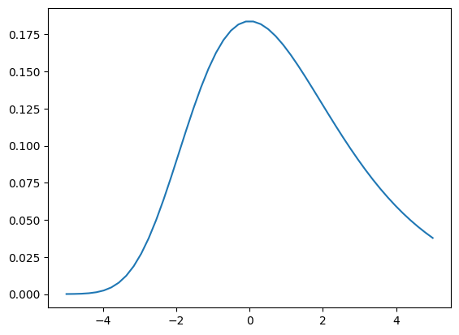

```python
gev = get_gev(xi=1e-5, sigma=2)
arr = np.linspace(-5, 5)

pdf = gev.prob(arr)
plt.plot(arr, pdf)
plt.show()
```

## Solution Exercise 1:

The cdf of the GEV distribution is well defined when $1 + \xi \left( \frac{z - \mu}{\sigma} \right) > 0$. This is equivalent to

$$ z > \mu - \frac{\sigma}{\xi} \qquad \text{if $\xi>0$} $$

and $$ z < \mu - \frac{|\sigma|}{\xi} \qquad \text{if $\xi<0$}. $$

Thus, for $\xi>0$, the distribution has a left boundary, the probability of points lying to the left of it is zero. The value of the cdf there is zero.

For $\xi<0$ there is a right boundary, the probability of points lying to the right of it is zero and the value of the cdf is 1.

As $\xi$ moves to zero from below, the right boundary is pushed to infinity. Similarly, if it approaches zero from above, the left boundary is pushed to negative infinity. At exactly $\xi=0$, the GEV becomes the Gumbel distribution which is well defined for all $z$.

We can group the numbers of calls according to the dates, thereby obtaining daily maxima and minima of calls. One way of detecting anomalies in the NYC taxi data set is by fitting a GEV to the distribution of these daily maxima. Here a histogram plot of the (normalized) maxima:

```python
daily_grouped = taxi_df.groupby("date")["n_calls"].agg(["max", "min", "sum"])
daily_grouped["diff"] = daily_grouped["max"] - daily_grouped["min"]
daily_grouped.head()
```

| date | max | min | sum | diff |
| --- | --- | --- | --- | --- |
| 2014-07-01 | 1.795669 | -1.884028 | 2.790492 | 3.679696 |
| 2014-07-02 | 1.691045 | -1.823358 | 1.014052 | 3.514403 |
| 2014-07-03 | 2.139658 | -1.756635 | -2.372237 | 3.896293 |
| 2014-07-04 | 0.481677 | -1.709367 | -25.080606 | 2.191043 |
| 2014-07-05 | 0.438732 | -1.819178 | -24.661968 | 2.257910 |

```python
daily_grouped_normalized = normalize(daily_grouped)
daily_grouped_normalized.head()
```

| date | max | min | sum | diff |
| --- | --- | --- | --- | --- |
| 2014-07-01 | 0.960450 | -0.714018 | 0.208709 | 1.261851 |
| 2014-07-02 | 0.718429 | -0.155274 | 0.075844 | 0.838539 |
| 2014-07-03 | 1.756184 | 0.459211 | -0.177427 | 1.816547 |
| 2014-07-04 | -2.079144 | 0.894527 | -1.875853 | -2.550535 |
| 2014-07-05 | -2.178485 | -0.116786 | -1.844541 | -2.379291 |

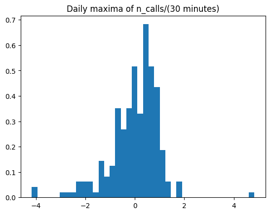

```python
plt.hist(daily_grouped_normalized["max"], density=True, bins=40)
plt.title("Daily maxima of n_calls/(30 minutes)")
plt.show()
```

**Q**: Can you already spot the obvious anomalies? What caused them?

**A**: See below

**Q**: Which of the three qualitatively different shapes would make "physical" sense for the taxi calls data?

**A**: The Weibull shape - thus we expect $\xi<0$.

```python
maxima = daily_grouped_normalized["max"]
maxima[(maxima > 1.8) | (maxima < -3.5)]
```

```
date
2014-09-06    1.885529
2014-11-02    4.827113
2014-12-25   -4.166655
2015-01-01    1.839858
2015-01-27   -4.010309
Name: max, dtype: float64
```

- 02/11 - NY marathon
- 25/12 - Christmas
- 27/01 - Snowstorm
- 01/01 - New Years
- 06/09 - Columbus day (big parade)

## Fitting the GEV

Now let us infer the parameters of the GEV from the data using maximum likelihood estimation. We will make gradient descent on the negative log likelihood of the GEV. Here a very simple training loop for a suitable initial choice for the shape parameter $\xi$ (it is called "concentration") written out in detail:

```
WARNING:absl:At this time, the v2.11+ optimizer `tf.keras.optimizers.SGD` runs slowly on M1/M2 Macs, please use the legacy Keras optimizer instead, located at `tf.keras.optimizers.legacy.SGD`.
```

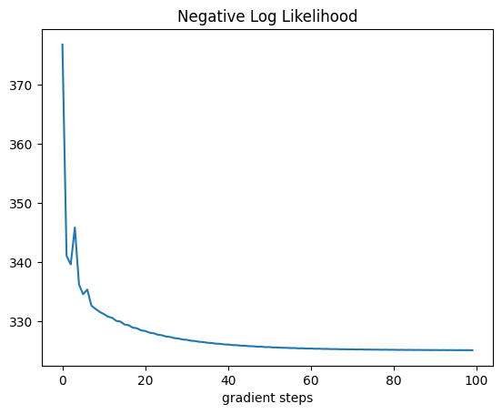

```python
# we are going to be a bit fancy and show an animation of the function as it is being fitted

daily_max = daily_grouped_normalized["max"].values

optimizer = keras.optimizers.SGD(learning_rate=2e-4)
losses = []

sample_gev = get_gev(xi=-0.1, trainable_xi=True)

fig = plt.figure(dpi=200, figsize=(4.5, 3))
camera = Camera(fig)

for step in range(100):
    with tf.GradientTape() as tape:
        loss = - tf.math.reduce_sum(sample_gev.log_prob(daily_max))
    gradients = tape.gradient(loss, sample_gev.trainable_variables)
    optimizer.apply_gradients(zip(gradients, sample_gev.trainable_variables))
    losses.append(loss)

    bins = plt.hist(daily_max, bins=40, density=True, color="C0")[1]
    pdf = sample_gev.prob(bins)
    plt.plot(bins, pdf, color="orange")
    ax = plt.gca()
    ax.text(0.5, 1.01, f"{step=}, Loss={loss}", transform=ax.transAxes)
    camera.snap()

plt.close()
plt.figure()
plt.plot(losses)
plt.title("Negative Log Likelihood")
plt.xlabel("gradient steps")
plt.show()
```

Seems like after 100 steps we have already converged. Let us have a quick look at the result

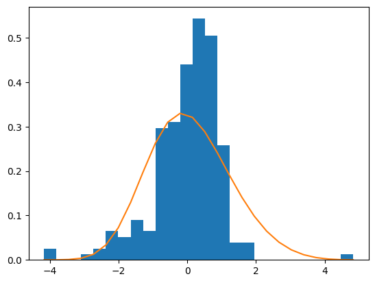

```python
bin_positions = plt.hist(daily_max, density=True, bins=25)[1]
plt.plot(bin_positions, sample_gev.prob(bin_positions))
plt.show()
```

```python
sample_gev.trainable_variables
```

```
(<tf.Variable 'xi:0' shape=() dtype=float64, numpy=-0.19605527604088643>,
 <tf.Variable 'mu:0' shape=() dtype=float64, numpy=-0.3901123713168851>,
 <tf.Variable 'sigma:0' shape=() dtype=float64, numpy=1.1369220029896918>)
```

Well, we probably can do better...

## Exercise 2.1: MLE for the generalized extreme value distribution

Find a better fit using:

1. Removing the obvious anomalies
2. Profiling in the shape parameter $\xi$ or using different initial values/learning rates for inferring $\xi$

Feel free to improve the code by defining new functions and so on!

Evaluate the quality of your fit by visual inspection of a histogram and a Q-Q plot (more on that below).

You can also use other statistical tools that you are familiar with.

Use the fitted model to find "anomalies" for taxi calls corresponding to probabilities of less than $0.01$.

### Q-Q Plot

A Q-Q plot is useful for visually comparing two distributions, or comparing a distribution with a dataset. We are interested in the latter. In a Q-Q plot the quantiles of one distribution are plotted against the quantiles of another. For a dataset, the natural choice of quantiles is given simply by the sorted data itself. The data points then roughly correspond to the $\frac{k}{n+1}$th percentiles, where $n$ is the number of samples and $k=1,...,n$ (these are often called *plotting positions* and other choices for them are possible). The corresponding *theoretical quantiles* from some specified c.d.f. $F$ are then given by $q_k \ \text{s.t} \ F(q_k) = \frac{k}{n+1}$ (in our applications, $F$ will generally be injective and the $q_k$ uniquely defined).

If the distribution is a good fit of the data, the resulting line will be close to the diagonal. Below we ask you to complete a simple implementation of the Q-Q plot for tensorflow-like distributions

```python
ArrayLike = Sequence[Union[float, tf.Tensor]]


class TFDistributionProtocol(Protocol):
    name: str
    trainable_variables: Tuple[tf.Variable]

    def quantile(self, prob: ArrayLike) -> ArrayLike: ...
```

```python
def qqplot(data: ArrayLike, dist: TFDistributionProtocol):
    num_observations = len(data)
    observed_quantiles = sorted(data)
    plotting_positions = np.arange(1, num_observations + 1) / (num_observations + 1)
    theoretical_quantiles = dist.quantile(plotting_positions)

    plot_origin = (theoretical_quantiles[0], observed_quantiles[0])
    plt.plot(theoretical_quantiles, observed_quantiles)
    plt.plot(theoretical_quantiles, theoretical_quantiles) # adding a diagonal for visual comparison
    plt.xlabel(f"Theoretical quantiles of {dist.name}")
    plt.ylabel(f"Observed quantiles")
```

## Solution of exercise 2.1

```python
# setting up functions for normal and profile likelihood fit

def fit_dist(data: ArrayLike, dist: TFDistributionProtocol, num_steps=100, lr=1e-4,
             plot_losses=True, return_animation=True) -> Union[float, Tuple[float, HTML]]:
    optimizer = keras.optimizers.SGD(learning_rate=lr)
    losses = []

    if return_animation:
        fig = plt.figure(dpi=200, figsize=(4.5, 3))
        camera = Camera(fig)

    for step in range(num_steps):
        with tf.GradientTape() as tape:
            loss = - tf.math.reduce_sum(dist.log_prob(data))
        if np.isnan(loss.numpy()):
            logging.warning(f"Encountered nan after {step} steps")
            break

        gradients = tape.gradient(loss, dist.trainable_variables)
        optimizer.apply_gradients(zip(gradients, dist.trainable_variables))
        losses.append(loss)

        if return_animation:
            bins = plt.hist(data, bins=50, density=True, color="C0")[1]
            pdf = dist.prob(bins)
            plt.plot(bins, pdf, color="orange")
            ax = plt.gca()
            ax.text(0.5, 1.01, f"{step=}, Loss={round(loss.numpy(), 2)}", transform=ax.transAxes)
            camera.snap()


    if plot_losses:
        plt.close()
        plt.figure()
        plt.plot(losses)
        plt.title("Negative Log Likelihood")
        plt.xlabel("gradient steps")
        plt.show()

    result = losses[-1]
    if return_animation:
        result = result, HTML(camera.animate().to_html5_video())
    return result

def profile_fit_dist(data: ArrayLike, dist_factory: Callable[[float], TFDistributionProtocol], xi_values: Sequence[float],
                     num_steps=100, lr=1e-4) -> Tuple[float, TFDistributionProtocol]:
    """
    Fits the distribution to data and returns the final loss. If return_animation=True, returns the tuple
    (final_loss, animation)
    """
    minimal_loss = np.infty
    optimal_dist = None
    for xi in xi_values:
        dist = dist_factory(xi)
        loss = fit_dist(data, dist, num_steps=num_steps, lr=lr, plot_losses=False, return_animation=False)
        if loss < minimal_loss:
            minimal_loss = loss
            optimal_dist = dist
    if optimal_dist is None:
        raise RuntimeError(f"Could not find optimal dist, probably due to divergences during fit. "
                           "Try to find a better choice for xi_values")
    return minimal_loss, optimal_dist
```

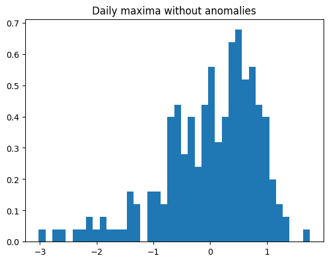

```python
# removing obvious anomalies
daily_max_without_anomalies = daily_max[np.logical_and( daily_max < 1.8, daily_max > -3.5)]

plt.hist(daily_max_without_anomalies, density=True, bins=40)
plt.title("Daily maxima without anomalies")
plt.show()
```

```python
# Example with profile likelihood

xi_values = np.linspace(-0.3, -0.5, 30)
dist_factory = lambda xi: get_gev(xi, trainable_xi=False)
min_loss, optimal_gev = profile_fit_dist(daily_max_without_anomalies, dist_factory, xi_values, num_steps=80)
print(f"Minimal loss: {min_loss}")
print(f"Optimal xi: {optimal_gev.concentration}")
optimal_gev.trainable_variables
```

[output not shown]

```
Minimal loss: 252.73708563392216
Optimal xi: -0.44482758620689655
```

```
(<tf.Variable 'mu:0' shape=() dtype=float64, numpy=-0.21253119412529123>,
 <tf.Variable 'sigma:0' shape=() dtype=float64, numpy=0.896378037612195>)
```

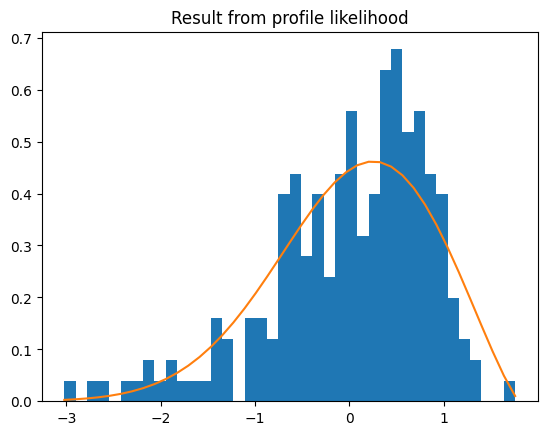

```python
bin_positions = plt.hist(daily_max_without_anomalies, density=True, bins=40)[1]
plt.plot(bin_positions, optimal_gev.prob(bin_positions))
plt.title("Result from profile likelihood")
plt.show()
```

```
WARNING:absl:At this time, the v2.11+ optimizer `tf.keras.optimizers.SGD` runs slowly on M1/M2 Macs, please use the legacy Keras optimizer instead, located at `tf.keras.optimizers.legacy.SGD`.
```

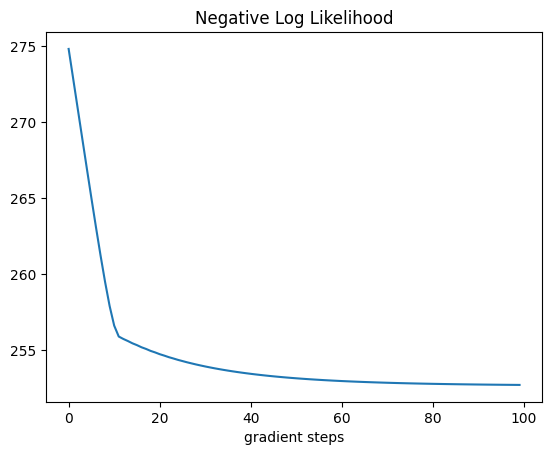

```python
# Solving with gradient descent on xi
daily_max_gev = get_gev(xi=-0.4)
final_loss = fit_dist(daily_max_without_anomalies, daily_max_gev, return_animation=False)
```

```python
# Here the values found by fitting
daily_max_gev.trainable_variables
```

```
(<tf.Variable 'xi:0' shape=() dtype=float64, numpy=-0.4490658772874973>,
 <tf.Variable 'mu:0' shape=() dtype=float64, numpy=-0.2153160679049942>,
 <tf.Variable 'sigma:0' shape=() dtype=float64, numpy=0.905020869171821>)
```

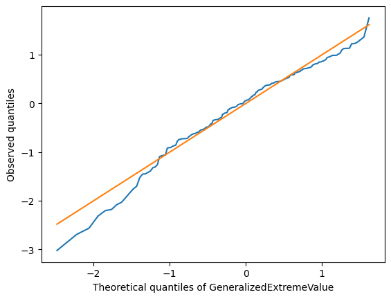

```python
# and here the qqplot
qqplot(daily_max_without_anomalies, daily_max_gev)
```

### Solution exercise 2.1 - Finding anomalies from the GEV

```python
#The fit looks quite good, apart from the lower region, which we are not really interested in.
#Let us find the anomalies corresponding to the upper 1% quantile
upper_percentile = 0.99
upper_quantile = daily_max_gev.quantile(upper_percentile).numpy()
upper_quantile
```

```
1.544639556561257
```

```python
# and here the anomalies above this threshold
daily_grouped_normalized["max"][daily_grouped_normalized["max"] > upper_quantile]
```

```
date
2014-07-03    1.756184
2014-09-06    1.885529
2014-11-02    4.827113
2015-01-01    1.839858
Name: max, dtype: float64
```

In addition to the obvious anomalies found above, we caught the independence day (one day before it). We also have the probabilistic interpretation that for 99% of the days the maximal amount of calls per 30 minutes will not exceed the threshold found above (it should be rescaled back to the original value for this statement to hold).

## Estimating the uncertainty

One benefit of the probabilistic approach is that we get confidence intervals almost for free. These can be used to estimate the robustness of our analysis (e.g. the determination of anomalies and the quality of the fit).

Since we fitted our functions using MLE, which is known to be approximately normal, we get uncertainty estimates from the second derivatives of the loss function. Fortunately, tensorflow makes this extremely easy for us.

```python
def observed_fisher_information(data: ArrayLike, dist: TFDistributionProtocol) -> tf.Tensor:
    with tf.GradientTape() as t2:
        with tf.GradientTape() as t1:
            nll = - tf.math.reduce_sum(dist.log_prob(data))
        # conversion needed b/c trainable_vars is a tuple, so gradients and jacobians are tuples too
        g = tf.convert_to_tensor(
            t1.gradient(nll, dist.trainable_variables)
        )
    return tf.convert_to_tensor(t2.jacobian(g, dist.trainable_variables))
```

```python
def mle_std_deviations(data: ArrayLike, dist: TFDistributionProtocol) -> tf.Tensor:
    observed_information_matrix = observed_fisher_information(data, dist)
    mle_covariance_matrix = tf.linalg.inv(observed_information_matrix)
    variances = tf.linalg.tensor_diag_part(mle_covariance_matrix)
    return tf.math.sqrt(variances)
```

## Exercise 2.2: Uncertainty in GEV

Using the above functions, include error bars into the Q-Q plots of the maximum likelihood estimates of the GEV distribution found above.

## Solution Exercise 2.2

```python
# finding the stddevs and adding/substracting them from the values found from fitting
std_devs = mle_std_deviations(daily_max_without_anomalies, daily_max_gev)
print(f"Found std_devs: {std_devs}")

coeff_fitted = tf.convert_to_tensor(daily_max_gev.trainable_variables)
coeff_upper = coeff_fitted + std_devs
coeff_lower = coeff_fitted - std_devs

# creating GEVs corresponding to the boundaries of the confidence intervals found above
gev_upper = get_gev(*coeff_upper)
gev_lower = get_gev(*coeff_lower)
```

```
Found std_devs: [0.02618123 0.06607897 0.04556484]
```

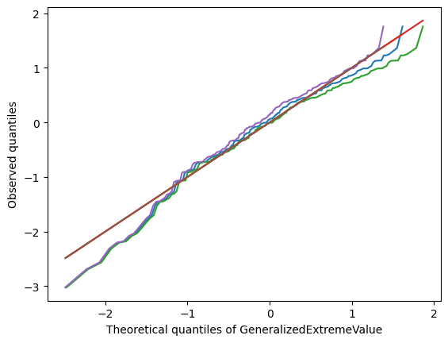

```python
# The qqplots for the original GEV and the GEVs at the boundaries

qqplot(daily_max_without_anomalies, daily_max_gev)
qqplot(daily_max_without_anomalies, gev_upper)
qqplot(daily_max_without_anomalies, gev_lower)
```

## Exercise 3: GEV for minima

Now let us repeat the same analysis fitting the distribution of the daily minima using the same strategy. Since minima for a univariate random variable $X$ correspond to maxima of $-X$, all we have to do is to fit a GEV to the minima multiplied by -1.

## Solution of exercise 3

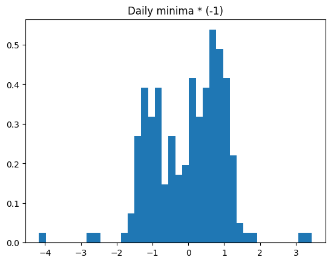

```python
neg_minima_series = -daily_grouped_normalized["min"]
neg_daily_min = neg_minima_series.values

plt.hist(neg_daily_min, density=True, bins=40)
plt.title("Daily minima * (-1)")
plt.show()
```

```python
# identifying obvious anomalies
neg_minima_series[(neg_minima_series>2) | (neg_minima_series<-2)]
```

```
date
2014-11-01   -4.168684
2014-11-02   -2.561467
2015-01-01   -2.683568
2015-01-26    3.202483
2015-01-27    3.442703
Name: min, dtype: float64
```

```python
# - 01/01 - New Year
# - 01-02/11 - Marathon
# - 26-27/01 - Snowstorm
```

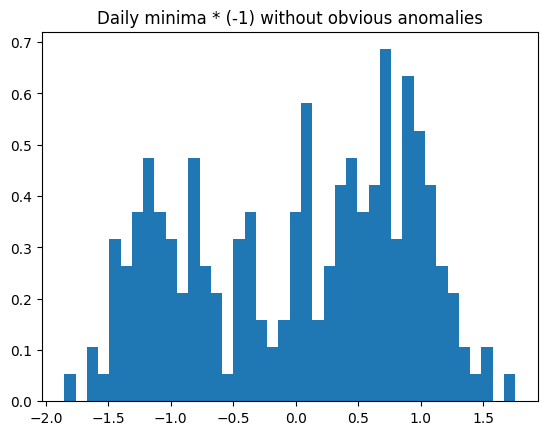

```python
neg_minima_without_anomalies = neg_daily_min[np.logical_and(neg_daily_min<2, neg_daily_min>-2)]
plt.hist(neg_minima_without_anomalies, density=True, bins=40)
plt.title("Daily minima * (-1) without obvious anomalies")
plt.show()
```

```
WARNING:absl:At this time, the v2.11+ optimizer `tf.keras.optimizers.SGD` runs slowly on M1/M2 Macs, please use the legacy Keras optimizer instead, located at `tf.keras.optimizers.legacy.SGD`.
```

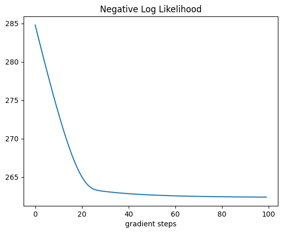

```python
daily_min_gev = get_gev(xi=-0.3)
final_loss = fit_dist(neg_minima_without_anomalies, daily_min_gev, return_animation=False)
```

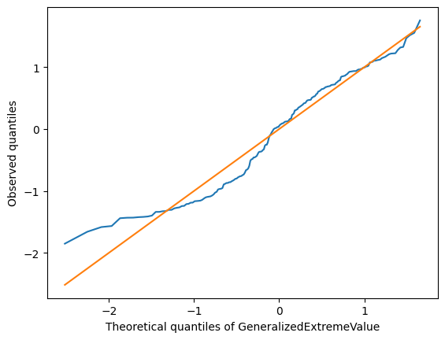

```python
qqplot(neg_minima_without_anomalies, daily_min_gev)
```

```python
# Fit looks good in the region we are interested in, let us find the 1% quantile and the corresponding anomalies
```

```python
upper_quantile = daily_min_gev.quantile(0.99).numpy()
upper_quantile
```

```
1.5803475989870672
```

```python
neg_minima_series[neg_minima_series>upper_quantile]
```

```
date
2015-01-26    3.202483
2015-01-27    3.442703
2015-01-28    1.755855
Name: min, dtype: float64
```

```python
# Only one non-obvious anomaly is found in the upper quantile, it is cause by the snowstorm responsible for the obvious anomalies we have seen above.
```

## Comparison with Z-Test

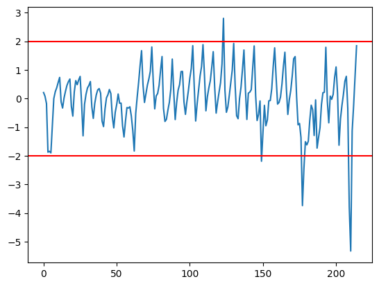

```python
daily_means = daily_grouped_normalized["sum"]

plt.plot(daily_means.values)
plt.axhline(y=2., color='r', linestyle='-')
plt.axhline(y=-2., color='r', linestyle='-')
plt.show()
```

The big question here is: where to put the threshold? Clearly the assumption of a Gaussian distribution underlying the sum of daily calls is incorrect - the distribution seems skewed.

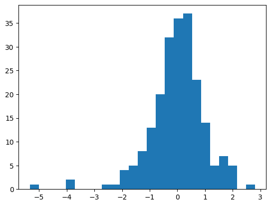

```python
plt.hist(daily_means, bins=25)
plt.show()
```

We can detect some anomalies with the Z-test, of course, but the probabilistic interpretation is going to be flawed.

```python
daily_means[np.abs(daily_means) > 2]
```

```
date
2014-11-01    2.802000
2014-11-27   -2.192533
2014-12-25   -3.743349
2014-12-26   -2.452098
2015-01-26   -3.786365
2015-01-27   -5.330402
Name: sum, dtype: float64
```

## A look back at the theory

So, what have we really done and why does it make sense to use the GEV for such problems? What kind of guarantees does the Fisher-Tipett-Gnedenko theorem give us about the quality of the fit?

Well, the truth is, not too many. First notice the following exact equality:

$$ P(M_n < z) = P(X_1< z \text{ and } X_2 < z ... \text{ and } X_n < z) = F^n(z) $$

So, if we know the cumulative distribution, there is no need to resort to the GEV. Typically, of course, we do not know it. The above equality implies:

$$ \lim P(M_n < z) = \begin{cases} 0 & \text{if}\ F(z) < 1 \\ 1 & \text{otherwise} \end{cases} $$

We actually always know the exact limit of the distribution of the block-maxima! It is degenerate (either a step function of identical zero). In fact, this degenerate distribution can be seen as a limit of the GEV. It would correspond to normalizing constants $a_n=1, \ b_n=0$.

While this observation is very simple and the difference between the cdf of block maxima $P(M_n < z)$ and its degenerate limit does decrease as $n$ increases, this limiting distribution is unexpressive and fitting it to data does not provide probabilistic insight.

**Q**: How many parameters does the exact limit of $F^n$ have? What would we get if we fit it to data?

**A**:

Introducing the normalizing constants $a_n$ and $b_n$ *might* allow the distribution of renormalized block maxima to converge to something non-trivial. It also might not.

In applications we usually care about modeling $M_n$ for a *fixed $n_0$* (or maybe for a few selected $n_i$). An arbitrary series of $a_n$ and $b_n$ that at some point helps convergence does not directly address our needs. In fact, this is also not what we do - by fitting the GEV parameters to data for our selected $n_0$ we automatically find the *best* $a_{n_0}$ and $b_{n_0}$ that minimize the difference between $F^{n_0}(z)$ and $G(z)$.

Clearly $G(z)$ is much more expressive than the degenerate exact limit and could potentially provide a good fit.

So, the convergence that we really care about is to answer the question:

How well do the best fits of $G(z)$ for fixed $n$ - let us call them $G_n(z)$ - approximate the distributions $F^n(z)$ as $n$ increases? One could e.g. be interested in the infinity norm

$$ \Delta_n := \sup_z | F^n(z) - G_n(z) | $$

This is not the same as asking how well $G(z)$ approximates some rescaled variant of $F^n(z)$ with $n$-dependent normalization constants! That would be

$$ \tilde{\Delta}_n(a_n, b_n) := \sup_z |F^n(a_n z + b_n) - G(z) | $$

In the latter question, the choice of normalization constants matters, in the former it does not - they are implicitly determined by the best fit for each $n$. Since for $\Delta_n$ the $a_n, b_n$ have been optimized, one could reasonably expect a relation of the type

$$ \Delta_n \approx \min_{a_n, b_n} \tilde{\Delta}_n(a_n, b_n) $$

to hold.

It is easy to see that given some normalizing sequences $a_n, b_n$, the convergence to a GEV is possible, than with other sequences $\tilde{a}_n, \tilde{b}_n$ with some $a>0, b$ such that

$$ \lim_{n\rightarrow \infty} \frac{\tilde{a}_n}{a_n} = a \quad,\quad \lim_{n \rightarrow \infty} \frac{b_n-\tilde{b}_n}{a_n} = b $$

the rescaled $\frac{M_n-\tilde{b}_n}{\tilde{a_n}}$ also converges to a GEV of the same type (with the same $\xi$). This is often formulated that a distribution $F$ has *a fixed domain of attraction*. However, the error rates $\tilde{\Delta}_n(\tilde{a}_n, \tilde{b}_n)$ would be different from those associated to $a_n, b_n$.

Unfortunately, theoretical bounds for the quantity of interest $\Delta_n$ are hard to come by - we are not aware of any. They also highly depend on the fitting procedure, which is non-trivial, as we have seen above. There are some bounds for quantities of the type $\tilde{\Delta}_n(\tilde{a}_n, \tilde{b}_n)$ (see the annotated literature reference) but they are rather loose and not really helpful in practice. Therefore, the EVT theorems are more of a motivation for selecting distribution families for fitting than a rigorous approach with guarantees. In practice the convergence and fit tend to work pretty well, though.

## Exercise 4 (theoretical, bonus): outlining the proof of the Fisher-Gnedenko-Tripet theorem

One may wonder how the statement of the Fisher-Gnedenko-Tripet theorem is obtained without providing bounds on convergence. The reason is that the limiting distribution of (renormalized) maxima must have a very special property - it must be max stable. It is instructive to go through a part of the proof to get a feeling for the EVT theorems. We will do so in this exercise.

**Definition**: A cumulative distribution function $D(z)$ is called *max-stable* iff for all $n\in\mathbb{N} \ \exists \ \alpha_n>0, \beta_n \in \mathbb{R}$ such that

$$ D^n(z) = D(\alpha_n z + \beta_n) $$

Prove that from $\lim_{n\rightarrow \infty} P\left( \frac{M_n - b_n}{a_n} < z \right) = G(z)$ follows that $G(z)$ is max-stable.

This goes a long way towards proving the first EVT theorem. One can easily compute that the GEV distribution is max-stable and with more effort one can also prove that any max-stable distribution belongs to the GEV family. Thus, the proof of the theorem is very implicit and does not involve any convergence rates or bounds.

## Exercise 5: increase the block size

According to the line of thought above, increasing the block-size before determining the maxima should improve convergence. Of course, it also decreases the number of points for fitting so it increases variance. We will analyze uncertainties of the fitted GEV below.

Repeat the fit of the GEV for 2-day maxima/minima. What do you think about the result?

*Hint: use the .reshape method of numpy arrays on the already computed daily maxima/minima*

## Solution exercise 5:

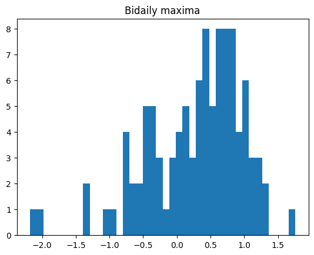

```python
bidaily_maxima = daily_max_without_anomalies.reshape(-1, 2).max(axis=1)

plt.hist(bidaily_maxima, bins=40)
plt.title("Bidaily maxima")
plt.show()
```

```
WARNING:absl:At this time, the v2.11+ optimizer `tf.keras.optimizers.SGD` runs slowly on M1/M2 Macs, please use the legacy Keras optimizer instead, located at `tf.keras.optimizers.legacy.SGD`.
```

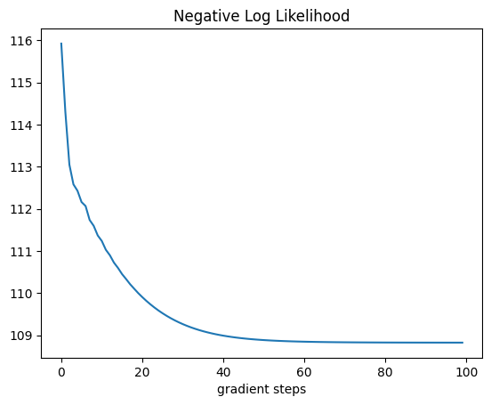

```python
bidaily_gev = get_gev(xi=-0.5)
loss = fit_dist(bidaily_maxima, bidaily_gev, lr=3e-4, num_steps=100, return_animation=False)
```

```python
bidaily_gev.trainable_variables
```

```
(<tf.Variable 'xi:0' shape=() dtype=float64, numpy=-0.4352171270495099>,
 <tf.Variable 'mu:0' shape=() dtype=float64, numpy=0.0737917439054841>,
 <tf.Variable 'sigma:0' shape=() dtype=float64, numpy=0.7643633709060534>)
```

The shape parameter should be independent of the size of the block (it is not affected by $a_n$ and $b_n$) . Of course, since we find it from fitting, we shouldn't be surprised to find a slightly different value.

We get a better fit than before (less than half of the loss with half as many data points). But we have higher variance in the very important shape parameter $\xi$

```python
std_devs_daily = mle_std_deviations(daily_max_without_anomalies, daily_max_gev)
std_devs_bidaily = mle_std_deviations(bidaily_maxima, bidaily_gev)

print("Daily stddevs:")
print(std_devs_daily.numpy())
print("Biaily stddevs:")
print(std_devs_bidaily.numpy())
```

```
Daily stddevs:
[0.02618123 0.06607897 0.04556484]
Biaily stddevs:
[0.03952068 0.07958698 0.05549258]
```

# Peaks over threshold (PoT)

So far we have only used the first theorem of EVT. As you might have noticed above, it can be somehow wasteful when it comes to data efficiency. Since the GEV is fitted on block-maxima, a huge number of data points remain unused for parameter estimation. The second theorem of EVT gives rise to a more efficient approach

## Exercise 6 (theoretical, bonus): deriving the second theorem of EVT

Use the approximation $\ln(1+x) \approx 1 + x$ for $|x| \ll 1$ and $F(z) \approx 1$ for large enough $z$ to derive.

\begin{equation} P(X-u < y \mid X > u) \approx 1 - \left( 1 + \frac{\xi \ y}{\tilde{\sigma}} \right)^{-\frac{1}{\xi}} \label{GPD-approx-original} \end{equation}

for large enough $u$ (this is a slightly less formal derivation of Pickards' et. al. theorem). One could equivalently write

\begin{equation} P(X-u > y \mid X > u) \approx \left( 1 + \frac{\xi \ y}{\tilde{\sigma}} \right)^{-\frac{1}{\xi}} \end{equation}

What is the relation between $\tilde{\sigma}$ and the normalizing coefficients of the first theorem of EVT?

The above equation can be used to estimate the entire tail of the cdf $F$ of $X$ from a sample of size $N$ obtained by sampling repeatedly from $F$. First note that for a single $u$ we can approximate the cdf through the sample statistics as:

\begin{equation} 1-F(u) = P(X>u) \approx \frac{N_u}{N} \end{equation}

where $N_u$ is the number of samples with values above $u$. Interpreting $u$ as a threshold, we will call those samples *peaks over threshold* (PoT) and $N_u$ is simply their count.

**Q**: What should $u$ and the data set fulfill in order for the above approximation to be accurate?

**A**: It should be small enough such that many data points are larger than it. Then the approximation in $P(X>u) \approx \frac{N_u}{N}$ holds (the estimator is not too biased).

Now we can perform a series of approximations for $z>u$ to get to the tail-distribution. First using $P(X>u) \approx \frac{N_u}{N}$ we get

$$ P(X>z) = P(X>z \cap X>u) = P(X>z \mid X>u) P(X>u) \approx \frac{N_u}{N} P(X>z \mid X>u) $$

Now we use the GDP theorem to approximate

$$ P(X>z \mid X>u) = P(X-u > z -u \mid X>u) \approx \left( 1 + \frac{\xi (z-u)}{\tilde{\sigma}} \right)^{-\frac{1}{\xi}} $$

Putting everything together gives

$$ P(X>z) \approx \frac{N_u}{N} \left( 1 + \frac{\xi (z-u)}{\tilde{\sigma}} \right)^{-\frac{1}{\xi}} $$

**Q**: Intuitively, what does $u$ need to fulfill for both approximations to hold?

**A**: $u$ should be small enough such that the approximation $P(X>u) \approx \frac{N_u}{N}$ holds and sufficiently large such that the generalized pareto distribution is a good estimate of the tail of the distribution for values larger than $u$. Intuitively, it should be at the *beginning of the tail*, where for values larger than $u$ only the tail behavior plays a role - i.e. no more local extrema or other specifics of the underlying distribution of the data.

## Exercise 7: Using the GPD for anomaly detection

This exercise lets you explore the second theorem of EVT for anomaly detection. Here we let you calculate and code on your own, without giving too many hints. You can follow the GEV-fitting code above for solving this exercise. Feel free to ask for hints if you are stuck!

1. Using the results above, find an approximation of the upper quantile $z_q$ such that $P(X>z_q) < q$ (assuming $z_q > u$).
2. What is the relation of this quantile to the quantile of the generalized pareto distribution?
3. Select a threshold $u$ and fit the generalized pareto distribution to the peaks over this threshold using tensorflow-probability and the same tricks that were used above for fitting the GEV distribution. You might want to use the profile likelihood fitting.
4. Determine anomalies from the quantile function.
5. What advantages do you see in fitting the GPD with PoT compared to fitting GEV distribution using block-maxima for anomaly detection? What are the disadvantages?
6. Check the quality of your fit and perform an uncertainty analysis as above for the GEV.